# Assignment 6

## Try to submit as an HTML file

Print your Emory ID below

```python
print(2457321)
```

```
2457321
```

Import the "pandas" and "matplotlib.pyplot" library

```python
# Write your answer here:
import pandas as pd
import matplotlib.pyplot as plt
```

(a) Compute function for each individual (map)

- Import the datset "data/bmi.csv"
  - **Note that the column `Height` is in $cm$, and `Weight` is in $kg$**
- Write a lambda function for $ BMI = \frac{weight (kg)}{height (m)^2} $
- Use `list(map(...))` to calculate $BMI$ for each row of the dataset
- Round the outcome into 2 decimal points
- Store the calculation in a new column in the dataframe called `BMI`
- Display the dataframe

```python
# Write your own code here

df = pd.read_csv("data/bmi.csv")

bmi_calculator = lambda row: round(row.Weight / ((row.Height / 100) ** 2), 2)

df['BMI'] = list(map(bmi_calculator, df.itertuples(index=False)))

print(df)
```

```
     Gender  Height  Weight  Index    BMI
0      Male     174      96      4  31.71
1      Male     189      87      2  24.36
2    Female     185     110      4  32.14
3    Female     195     104      3  27.35
4      Male     149      61      3  27.48
..      ...     ...     ...    ...    ...
495  Female     150     153      5  68.00
496  Female     184     121      4  35.74
497  Female     141     136      5  68.41
498    Male     150      95      5  42.22
499    Male     173     131      5  43.77

[500 rows x 5 columns]
```

For questions (b)-(d), read "data/wdi_2020.csv"

- This is a dataset containing the proportion  
  of urban population by country in 2020

(b) Convert to upper case

- Create the following function to convert a string to upper case

$\quad$ `fn_upper = lambda x: x.upper()`

- Create a new column, "countryname_upper"  
  that converts "countryname" to upper case.
- Print the original `countryname` and the newly created column, like:  
  "['Afghanistan', 'Africa Eastern and Southern', 'Africa Western and Central', 'Albania', 'Algeria', ......] "

```python
# Write your own code here

df = pd.read_csv("data/wdi_2020.csv")

fn_upper = lambda x: x.upper()

df['countryname_upper'] = df['countryname'].apply(fn_upper)

original_countryname = df['countryname'].tolist()
upper_countryname = df['countryname_upper'].tolist()

print("Original countryname:")
print(original_countryname)
print("\nNewly created column 'countryname_upper':")
print(upper_countryname)
```

```
Original countryname:
['Afghanistan', 'Africa Eastern and Southern', 'Africa Western and Central', 'Albania', 'Algeria', 'American Samoa', 'Andorra', 'Angola', 'Antigua and Barbuda', 'Arab World', 'Argentina', 'Armenia', 'Aruba', 'Australia', 'Austria', 'Azerbaijan', 'Bahamas, The', 'Bahrain', 'Bangladesh', 'Barbados', '…

Newly created column 'countryname_upper':
['AFGHANISTAN', 'AFRICA EASTERN AND SOUTHERN', 'AFRICA WESTERN AND CENTRAL', 'ALBANIA', 'ALGERIA', 'AMERICAN SAMOA', 'ANDORRA', 'ANGOLA', 'ANTIGUA AND BARBUDA', 'ARAB WORLD', 'ARGENTINA', 'ARMENIA', 'ARUBA', 'AUSTRALIA', 'AUSTRIA', 'AZERBAIJAN', 'BAHAMAS, THE', 'BAHRAIN', 'BANGLADESH', 'BARBADOS', '…
```

(c) Extract sorted elements from a dataset

- Sort by "prop_urbanpopulation" in ascending order
- Subset the 5 countries with the lowest urban population

```python
# Write your code here
df_sorted = df.sort_values(by='prop_urbanpopulation')

lowest_urban_population = df_sorted.head(5)

print("Subset of 5 countries with the lowest urban population:")
print(lowest_urban_population[['countryname', 'prop_urbanpopulation']])
```

```
Subset of 5 countries with the lowest urban population:
          countryname  prop_urbanpopulation
191  Papua New Guinea                13.345
34            Burundi                13.708
141     Liechtenstein                14.416
177             Niger                16.626
149            Malawi                17.427
```

(d) Subset elements with query

- Compute the 25 quantile value of "prop_urbanpopulation"
- Use ".query()" to subset countries with  
  "prop_urbanpopulation" higher the 25 quantile

**hint: Import `numpy` and use `np.nanpercentile`**

```python
# Write your own code here
import numpy as np

threshold = np.nanpercentile(df['prop_urbanpopulation'], 25)
high_urban_population = df.query('prop_urbanpopulation > @threshold')

print(f"Threshold (25th percentile): {threshold}")
print("\nSubset of countries with prop_urbanpopulation higher than the 25th percentile:")
print(high_urban_population[['countryname', 'prop_urbanpopulation']])
```

```
Threshold (25th percentile): 42.492392115

Subset of countries with prop_urbanpopulation higher than the 25th percentile:
                    countryname  prop_urbanpopulation
2    Africa Western and Central             47.857831
3                       Albania             62.112000
4                       Algeria             73.733000
5                American Samoa             87.153000
6                       Andorra             87.916000
..                          ...                   ...
258               Venezuela, RB             88.279000
260       Virgin Islands (U.S.)             95.939000
261          West Bank and Gaza             76.719000
262                       World             56.063764
264                      Zambia             44.629000

[197 rows x 2 columns]
```

(e) Plot by category

- Read "data/wdi_urban.csv"  
  This contains data from 1980 and 2020
- Create a list with the unique values of "year"
- Create a plot with a ...
  - Histogram of "prop_urbanpopulation"  
    for each year
  - Set the histogram option `alpha = 0.5` for transparency
  - All the histograms should be overlapping
  - Create a legend with the list of years
  - Label the axes and the title

What do we learn from the graph?

HINT: See the example at the end of Lecture 10

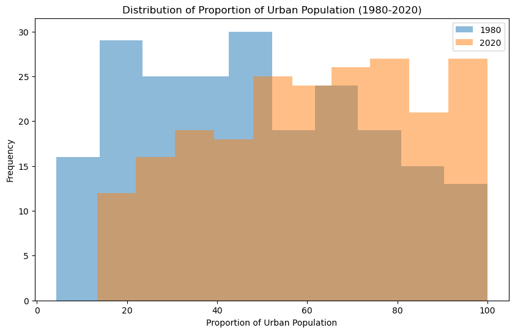

```python
# Write your own code here
df_urban = pd.read_csv("data/wdi_urban.csv")

years = df_urban['year'].unique()

plt.figure(figsize=(10, 6))

for year in years:
    data_year = df_urban[df_urban['year'] == year]
    plt.hist(data_year['prop_urbanpopulation'], bins=10, alpha=0.5, label=str(year))

plt.legend()
plt.xlabel('Proportion of Urban Population')
plt.ylabel('Frequency')
plt.title('Distribution of Proportion of Urban Population (1980-2020)')

plt.show()
```

This shows the increase in the proportion of people living in urban arieas from 1980 compared to 2020.